[figure not shown]

# Completing Panini albums.

Posted on Thu 07 November 2019 in analysis

Using jupyter notebook, to figure out how many packet I need to buy.

# Question: How many stickers do you need to buy to complete a Panini album ?

Panini stickers album are famous ( especially during soccer world cup ) in many school yard, where multiple exchange of duplicate are taking place in order to achieve the evasive completion of an album. I am not sure I have ever been able to complete fully an album when I was a kid. This bring the question, what does it takes to be able to complete an album. First we will look at it without the possibility of exchange between collectors. Off course now as a parent the number of packet needed to purchase reveals the sad reality of cost.

```python
# N total number of stickers in the album
N = 662

import math
import matplotlib.pyplot as plt

class album:
    def __init__(self, Nstickers):
        # Album start empty. making it private
        self.__album = {i:0 for i in range(1,Nstickers+1)}
        self.__Nstickers = Nstickers
    def addSticker(self,sticker_number):
        if sticker_number <= self.__Nstickers:
            self.__album[sticker_number] += 1
        else:
            print("Not a valid number.")
    def isAlbumFull(self):
        return all([v >= 1 for v in self.__album.values()])
    def countGot(self):
        return sum([v >= 1 for v in self.__album.values()])
    def duplicates(self):
        return sum([v > 1 for v in self.__album.values()])
    def display(self):
        plt.plot([self.__album[n] for n in self.__album.keys()])
        plt.ylabel('Sticker Count')
        plt.xlabel('Sticker Number')
        plt.show()
```

```
Matplotlib is building the font cache; this may take a moment.
```

```python
import random
def packet(Sticker_in_packet = 5, Nalbum=N):
    return random.sample(range(1,Nalbum+1), k=Sticker_in_packet)
```

```python
a = album(N)
```

```python
print(a.isAlbumFull(),a.countGot(),a.duplicates())
```

```
False 0 0
```

```python
def fill_album(album,limit=50):
    packet_bought = 0
    tracker = []
    while not album.isAlbumFull():
        packet_bought += 1
        for card in packet():
            album.addSticker(card)
        tracker.append([album.countGot(),album.duplicates(),album.isAlbumFull()])
        if album.countGot() - N < limit:
            #print('INFO can buy the remaining',packet_bought)
            if packet_bought > N*10:
                return tracker
    return tracker
```

```python
t = fill_album(a)
```

```python
t[-1]
```

```
[662, 655, True]
```

```python
def plot_tracker(tracker):
    plt.figure()
    plt.subplot(211)
    plt.plot([y[0] for y in tracker])
    plt.axhline(y=N-50,linewidth=4, color='r')
    plt.ylabel('Sticker filled')
    plt.xlabel('number of packet bought')
    plt.subplot(212)
    plt.plot([y[1] for y in tracker])
    plt.ylabel('Duplicates')
    plt.xlabel('number of packet bought')
    plt.show()

def plot_filled(tracker):
    plt.plot([y[0] for y in tracker])
    plt.axhline(y=N-50,linewidth=4, color='r')
    plt.ylabel('Sticker filled')
    plt.xlabel('number of packet bought')
    plt.show()

def plot_duplicate(tracker):
    plt.plot([y[1] for y in tracker])
    plt.ylabel('Duplicates')
    plt.xlabel('number of packet bought')
    plt.show()
```

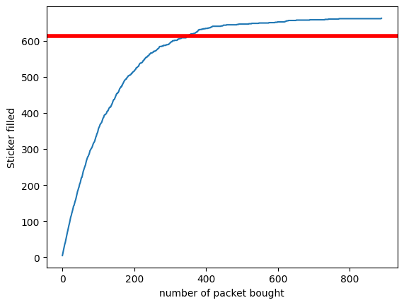

```python
plot_filled(t)
```

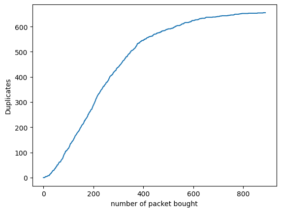

```python
plot_duplicate(t)
```

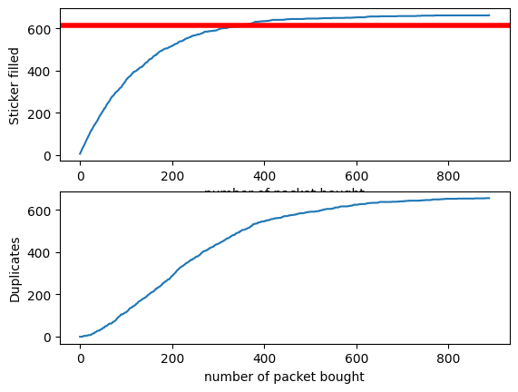

```python
plot_tracker(t)
```

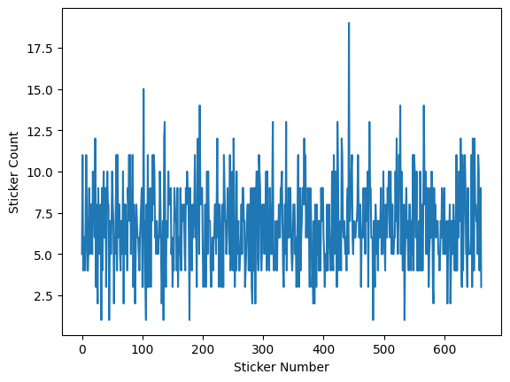

```python
a.display()
```

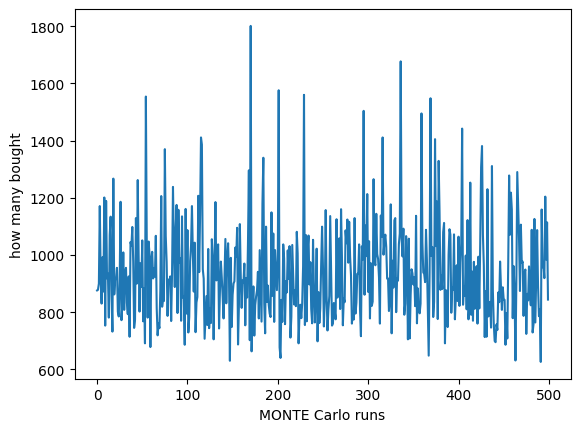

```python
#Monte Carlo
n_monte_carlo = 500
y1 = []
y2 = []
for i in range(n_monte_carlo):
    am = album(N)
    t = fill_album(am)
    y1.append(len(t))
    y2.append(t[-1])

plt.plot(y1)
plt.ylabel('how many bought')
plt.xlabel('MONTE Carlo runs')
plt.show()
```

```python
print("Average",sum(y1)/len(y1),"Max",max(y1),"Min",min(y1))
```

```
Average 938.13 Max 1801 Min 626
```

```python
y_dup = [yy[1] for yy in y2]
print("Mean",sum(y_dup)/len(y_dup))
```

```
Mean 654.924
```

```python
print("Max duplicates",max(y_dup),"Min duplicates",min(y_dup))
```

```
Max duplicates 661 Min duplicates 625
```

See below in the links few article which examined the problem.

Other references: Reference

http://wjgsp.com/number-packs-panini-album/

https://stats.stackexchange.com/questions/101255/how-many-stickers-do-i-need-to-complete-my-fifa-panini-album

shown: https://youtu.be/vuGaez6oFvo

http://images.math.cnrs.fr/Petite-collection-d-informations.html?lang=fr

https://www.unige.ch/math/folks/velenik/Vulg/Paninimania.pdf

Python